# Исследование объявлений о продаже квартир

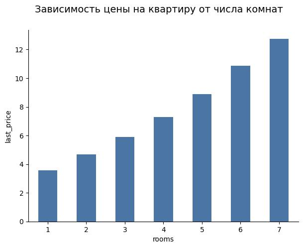

```python
fig = plt.figure(figsize=(7, 5))
fig.suptitle('Зависимость цены на квартиру от числа комнат', fontsize=14)
ax1 = fig.add_subplot(1, 1, 1)
(flats_df
    .groupby('rooms')['last_price'].median().reset_index()
    .plot(x='rooms', y='last_price', kind='bar', ax=ax1, color='#4A75A5', legend=False)
)
plt.ylabel('last_price')
plt.xticks(rotation = 0)

plt.show()
# построение столбчатой диараммы с зависимостью цены на квартиру от числа комнат
```

На графике выше видно, что увеличение количества комнат напрямую связано с повышением цены на квартиру.

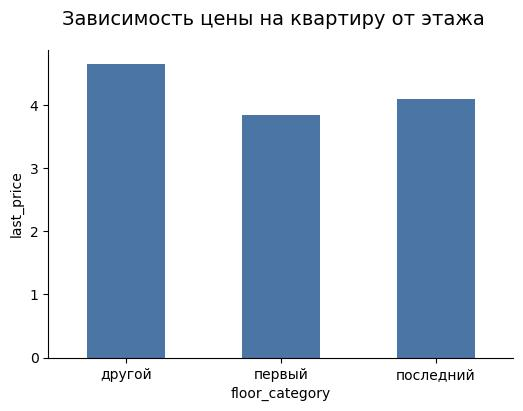

```python
fig = plt.figure(figsize=(6, 4))
fig.suptitle('Зависимость цены на квартиру от этажа', fontsize=14)
ax1 = fig.add_subplot(1, 1, 1)
(flats_df
    .groupby('floor_category')['last_price'].median().reset_index()
    .plot(x='floor_category', y='last_price', kind='bar', ax=ax1, color='#4A75A5', legend=False)
)
plt.ylabel('last_price')
plt.xticks(rotation = 0)

plt.show()
# построение столбчатой диараммы с зависимостью цены на квартиру от типа этажа
```

Первый этаж часто пользуется меньшим спросом у покупателей жилой недвижимости. Причин на этот счёт несколько - это опасения по поводу высокого шума, необходимость постоянно занавешивать окна, а также непосредственная близость подвалов.

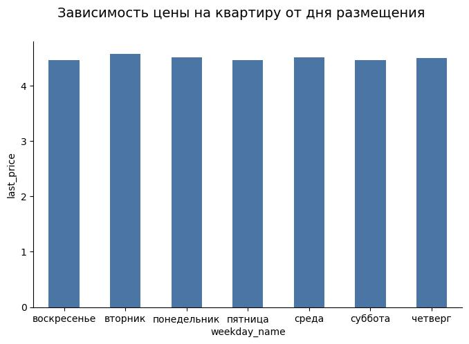

```python
fig = plt.figure(figsize=(8, 5))
fig.suptitle('Зависимость цены на квартиру от дня размещения', fontsize=14)
ax1 = fig.add_subplot(1, 1, 1)
(flats_df
    .groupby('weekday_name')['last_price'].median().reset_index()
    .plot(x='weekday_name', y='last_price', kind='bar', ax=ax1, color='#4A75A5', legend=False)
)
plt.ylabel('last_price')
plt.xticks(rotation = 0)

plt.show()
# построение столбчатой диараммы с зависимостью цены на квартиру от дня размещения объявления
```

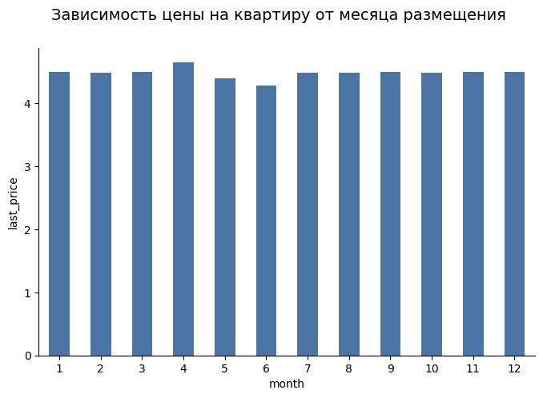

```python
fig = plt.figure(figsize=(8, 5))
fig.suptitle('Зависимость цены на квартиру от месяца размещения', fontsize=14)
ax1 = fig.add_subplot(1, 1, 1)
(flats_df
    .groupby('month')['last_price'].median().reset_index()
    .plot(x='month', y='last_price', kind='bar', ax=ax1, color='#4A75A5', legend=False)
)
plt.ylabel('last_price')
plt.xticks(rotation = 0)

plt.show()
# построение столбчатой диараммы с зависимостью цены на квартиру от месяца размещения объявления
```

Нет явной зависимости цены от дня и месяца размещения объявления. Можно отметить, что средняя цена на квартиры, выставленные на продажу **в апреле**, чуть выше, чем в остальные месяцы. Самые низкие цены наблюдаются у объявлений, размещённых **в июне**. Этот период характеризуется переходом от весенней активности на рынке к затишью и сниженному спросу на жильё, связанному с отпусками в начале лета.

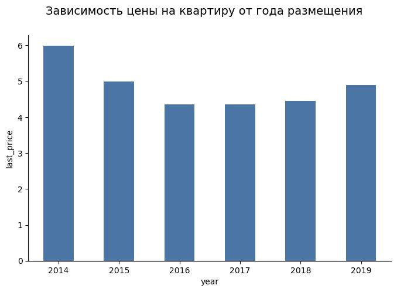

```python
fig = plt.figure(figsize=(8, 5))
fig.suptitle('Зависимость цены на квартиру от года размещения', fontsize=14)
ax1 = fig.add_subplot(1, 1, 1)
(flats_df
    .groupby('year')['last_price'].median().reset_index()
    .plot(x='year', y='last_price', kind='bar', ax=ax1, color='#4A75A5', legend=False)
)
plt.ylabel('last_price')
plt.xticks(rotation = 0)

plt.show()
# построение столбчатой диараммы с зависимостью цены на квартиру от года размещения объявления
```

Рассмотрим подробнее цены в 2014 году по месяцам.

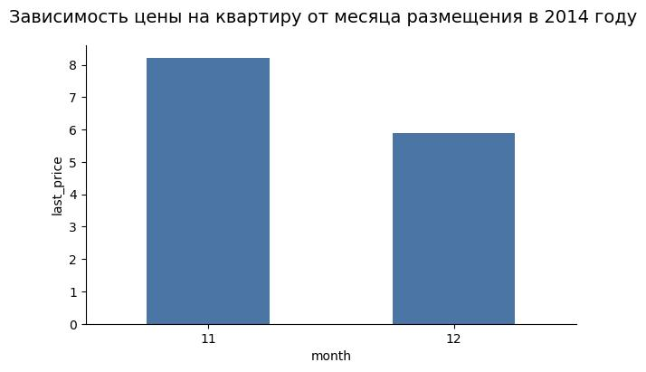

```python
fig = plt.figure(figsize=(7, 4))
fig.suptitle('Зависимость цены на квартиру от месяца размещения в 2014 году', fontsize=14)
ax1 = fig.add_subplot(1, 1, 1)
(flats_df
    .query('year == 2014')
    .groupby('month')['last_price'].median().reset_index()
    .plot(x='month', y='last_price', kind='bar', ax=ax1, color='#4A75A5', legend=False)
)
plt.ylabel('last_price')
plt.xticks(rotation = 0)

plt.show()
# построение столбчатой диараммы с зависимостью цены на квартиру от месяца размещения объявления в 2014 г.
```

```python
(flats_df
    .query('year == 2014')
    .groupby('month').agg(median_price=('last_price', 'median'), count_ads=('last_price', 'count'))
)
# группировка по месяцам в 2014 г. с подсчётом медианной цены
```

| month | median_price | count_ads |
| --- | --- | --- |
| 11 | 8.2 | 13 |
| 12 | 5.9 | 89 |

В течение всех шести лет самые высокие цены на квартиры были зафиксированы **в 2014 году**. По данным за два месяца, которые у нас есть в распоряжении, наибольшее количество квартир было продано *в декабре 2014 года*, при этом самые дорогие квартиры, хоть и в меньшем объёме, были выставлены на продажу *в ноябре 2014 года*. Этот резкий подъём, скорее всего, был связан с кризисом 2014 года, который вызвал повышенный интерес к рынку недвижимости. В условиях обвала рубля люди спешили купить недвижимость в надежде сохранить свои средства.

### Посчитайте среднюю цену одного квадратного метра в 10 населённых пунктах с наибольшим числом объявлений.

```python
(flats_df
    .groupby('locality_name').agg(mean_price=('price_for_square_meter', 'mean'), count_ads=('price_for_square_meter', 'count'))
    .sort_values(by='count_ads', ascending=False)
    .head(10)
    .sort_values(by='mean_price', ascending=False)
)
# создание сводной таблицы, выбор топ-10 населённых пунктов с наибольшим числом объявлений и сортировка средней цены за квадратный метр по убыванию
```

| locality_name | mean_price | count_ads |
| --- | --- | --- |
| Санкт-Петербург | 107533.554501 | 14382 |
| Пушкин | 101252.294087 | 345 |
| Кудрово | 95323.603199 | 472 |
| Парголово | 90269.764632 | 326 |
| Мурино | 85988.749729 | 590 |
| Шушары | 78649.030228 | 439 |
| Колпино | 75350.246131 | 336 |
| Гатчина | 68839.553816 | 304 |
| Всеволожск | 67141.546177 | 395 |
| Выборг | 58229.584914 | 232 |

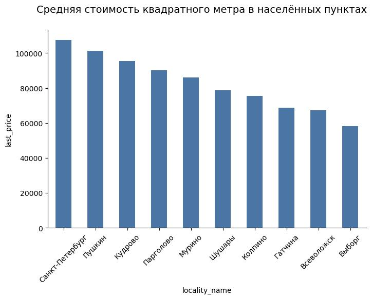

```python
fig = plt.figure(figsize=(8, 5))
fig.suptitle('Средняя стоимость квадратного метра в населённых пунктах', fontsize=14)
ax1 = fig.add_subplot(1, 1, 1)
(flats_df
    .groupby('locality_name').agg(mean_price=('price_for_square_meter', 'mean'), count_ads=('price_for_square_meter', 'count')).reset_index()
    .sort_values(by='count_ads', ascending=False)
    .head(10)
    .sort_values(by='mean_price', ascending=False)
    .plot(x='locality_name', y='mean_price', kind='bar', ax=ax1, color='#4A75A5', legend=False)
)
plt.ylabel('last_price')
plt.xticks(rotation = 45)

plt.show()
# построение столбчатой диараммы
```

### Выделите квартиры в Санкт-Петербурге с помощью столбца locality_name и вычислите среднюю цену каждого километра.

Это задание было выполнено в пункте 2.3.1 в разделе Предобработка данных.

## Общий вывод

Таким образом, средняя квартира в общей выборке обладает площадью от 30 до 60 квадратных метров, высотой потолков 2.6 метра, имеет 1-2 комнаты и оценивается примерно в 4.5 миллиона рублей. Небольшие однокомнатные квартиры чаще всего представлены в форме студий, в результате перепланировки коммунальных помещений. Многокомнатные апартаменты с просторными помещениями, вероятно, являются пентхаусами или квартирами в реконструированных исторических домах.

Квартиры на первых этажах менее востребованы среди покупателей, в основном из-за близости к улице, подвалам и шуму от лифтов.

Медианный срок продажи квартиры на рынке составляет 92 дня, практически 3 месяца. Заметно меньше объявлений размещается в праздничные дни, в период каникул и выходных.

Наибольшее количество опубликованных объявлений относится к Санкт-Петербургу и поселку Мурино. С точки зрения стоимости за квадратный метр лидируют Санкт-Петербург, город Пушкин и деревня Кудрово, тогда как в Выборге можно найти более доступное жильё.

Среди факторов, оказывающих положительное воздействие на цену квартиры, следует выделить общую и жилую площадь, площадь кухни, высоту потолков, количество комнат, а также близость к центру города. Наиболее очевидная зависимость наблюдается между площадью и стоимостью жилья, если не учитывать выбросы. Цены сильнее всего варьируются в пределах центрального района, что, вероятно, обусловлено разнообразием типов представленного там жилья.

Медианная стоимость квартир, выставленных на продажу в конце 2014 года, была самой высокой по сравнению с другими годами и, вероятно, была обусловлена кризисом и паникой на рынке недвижимости.